# Sessions (Day 1)

**Day 1**

- **08/13/2024 | [[GitHub](https://github.com/rstudio/rstudio-conf/blob/master/2024/README.md)]**

### Navigating A Career In Data Science

```markdown
Tuesday, Aug 13 10:20 AM - 11:40 AM PDT
```

#### Beyond the Classroom: Unspoken Realities of a Data Science Career

**Session Info**

- Presenter: Brandon Sucher
- Expand your network
- Find your niche
- Advocate for yourself

#### GitHub: How To Tell Your Professional Story

**Session Info**

- Presenter: Abigail Haddad
- GitHub can demonstrate your problem solving approach
  - The code tells that story
- How you communicate and solve a problem (e.g., README)
  - Displaying broader set of tools (starting with Git)
- GitHub is the industry-standard, free, and creating a lasting portfolio that is likely to get looked at at some point
- Approach coding from the view that somebody else might be looking at it (putting stuff on GitHub from the beginning might help you do this)
- What to put on GitHub? Personal projects that show what you can do
  - Skill: What skill am I either trying to get or show that I have?
    - Look at the skills that the jobs you want to have are looking for
  - Interest: Pick things that interest you
  - Scope: Pick the smallest possible project that conveys what you’re trying to show (trying to show something from start to finish)
    - Scope it narrowly and build if you want to
  - Put them on your resume
- Good development practices
  - Easy to run
  - Easy to build on
  - Understandable
- Repo essentials
  - Modular (sections, not repeating yourself, functions)
  - All work in code (from start to finish)
  - Organized
  - Documented (README file)
  - Makes sense (viewer is able to understand why you built what you did for the problem that you’re trying to solve)
- What they see first (check your GitHub page to make sure)
  - Pinned repos (pinning repos that you want seen & hiding repos you don’t want seen)
    - 1 repo or up to 6
    - repos that do the best job that communicate the skills you’re trying to highlight
  - Recent commits
- Update your work
  - Think about what story you’re telling to tell; make sure it’s a good representation of what you’re doing

### Introducing Positron, a new data science IDE

```markdown
Tuesday, Aug 13 10:20 AM - 11:40 AM PDT
```

Positron discussions: https://github.com/posit-dev/positron/discussions

#### Introducing Positron

**Session Info**

- Presenter: Julia Silge
- [Sildes](https://speakerdeck.com/juliasilge/introducing-positron)
- [Positron](https://github.com/posit-dev/positron)
  - Next generation data science IDE
  - Multilingual/polyglot IDE (R & Python support currently)
  - Built on VS Code

#### Exploratory Data Analysis with Python in Positron

**Session Info**

- Presenter: Isabel Zimmerman
- Viewer pane
- Connections pane
- Help pane
- Plots pane

#### Debugging Data with the Positron Data Explorer

**Session Info**

- Presenter: Tom Mock
- A next-gen data explorer
  - Data viewer grid
  - Summary panel (summary statistics appropriate for data; measures of central tendencies for numeric data or unique values for categorical data, missing data, etc.)
  - Filter bar
- Grid design
  - Polyglot tool for in-memory dataframes
  - Highly scalable
  - Grid sort and multi-sort
  - Automatic column width
  - Monospaced fonts in the data grid
- Filter design (outside of data viewer)
  - Dedicated filter bar
  - Quick add filter
  - Special filters by type
- Summary panel design
  - Type and name
  - Missing data percentage
  - Summary statistics

#### Architecture and Design of Positron

**Session Info**

- Presenter: Jonathan McPherson
- Positron is a polyglot IDE focused on data science.
- It’s a Code OSS fork, like Visual Studio Code is.
- Positron’s language features exist in extensions.
- The language features use existing standards, like the Jupyter Protocol and the Language Server Protocol.
- Positron has a public API that lets anyone add new languages or features.
  - The way Positron is built allows Positron to be extended to other languages in the future (foundation upon more data science to be built)

### Beautiful And Effective Tables

```markdown
Tuesday, Aug 13 1:00 PM - 2:20 PM PDT
```

#### Adequate Tables? No, We Want Great Tables

**Session Info**

- Presenter: Richard Iannone
- [`gt` R package](https://gt.rstudio.com/)
- Initial goals
  - Comprehensive table structuring
  - Large selection of functions for formatting values (29 formatters that cover a ton of formatting tasks)
  - Flexible and easy-to-use methods for table styling
    - 3 methods
      - `tab_style()`
      - `tab_options()`
      - `opt_stylize()`
  - Table rendering to multiple output types
    - table data -> gt object -> output table
    - You shouldn’t have to change the table code depending on the output type
      - Three output types were targeted: HTML, LaTeX, RTF
        - LaTeX and RTF outputs underwent improvements over several improvements
        - HTML changes: speed and accessibility
        - .docx/Word output type was implemented (currently improving)
        - Looking to adding Excel and PowerPoint output
- Later goals
  - Useful across many disciplines and use cases
    - Added formatters both general and domain-specific
  - Localization options for users all over the world
    - Most formatting options have a `locale` option that ensures that numbers, dates/times, and even words fit the language and region
  - Good documentation to get you building quickly
  - Useful for Pharma’s specific table-making needs
- The future of gt
  - Row ordering functionality - so you don’t have to order rows beforehand
  - Improvements to footnotes - flexibility for affixing the marks
  - Excel output tables - it’s a popular file format
  - Overall better table-splitting - better options, more dependable
  - Integration with database tables - so it can be used as input data
  - Ways to better style text - e.g., styling spans of text in a cell
  - Methods for merging cells - right now: no way to merge adjacent cells
- [Great Tables Python package](https://posit-dev.github.io/great-tables/articles/intro.html)
  - Important features are there, secondary features coming later
  - [Python version examples](https://posit-dev.github.io/great-tables/examples/)
- [reactable](https://glin.github.io/reactable/) Package available in R and Python (newly released) - interactive data tables
- Questions
  - HTML tables are translated to typst

#### Context is King

**Session Info**

- Presenter: Shannon Pileggi
- Data stewardship: How do we insure data integrity?
- Source data context can and should be embedded in your data
  - Using variable labels (like in sas/SPSS/Stata)
  - `haven` R package allows use to import sas/SPSS/Stata data files and retain variable labels
- Assigning variable labels
  - `labelled::set_variable_labels()` or using base R
    - [`labelled` R package](https://cran.r-project.org/web/packages/labelled/index.html)
- [Blog post: The case for variable labels in R](https://www.pipinghotdata.com/posts/2022-09-13-the-case-for-variable-labels-in-r/)
- Applications
  - Data dictionary
  - Figures, labelled
    - `ggeasy::easy_labs()` to automatically substitute variable labels into ggplots
  - Tabling, labelled
    - `gtsummary::tbl_summary()` will use your variable label instead of variable name in output (gt has same behavior)

```r
flights_schema <- tibble::list(
  airlines_labelled,
  airports_labelled,
  flights_labelled,
  planes_labelled,
  weathers_labelled
)

# Creating a data dictionary
flights_dictionary <- flights_schema |>
  map(labelled::generate_dictionary) |>
  enframe() |>
  unnest(cols = value)
```

- In practice
  - 1. Maintain a csv with metadata
  - 2. Apply custom function for bulk label assignment (e.g., `croquett::set_derived_variable_labels()`); in an iterative framework if you have many lists

#### gtsummary: Streamlining Summary Tables for Research and Regulatory Submissions

**Session Info**

- Presenter: Daniel Sjoberg
- [`gtsummary` R package](https://www.danieldsjoberg.com/gtsummary/)

```r
# Simple, customizable code
trial |>
  tbl_summary(
    by = trt, # group by treatment (Drug A vs. Drug B)
    include = c(age, grade, response), # by characteristics
    statistic = all_continuous() ~ "{mean} ({sd})" # instead of default median
  )

trial |>
  tbl_summary(
    by = trt, # group by treatment (Drug A vs. Drug B)
    include = c(marker, response), # by characteristics
    missing = "no",
    statistic = list(marker = "{mean} ({sd})", response = "{p}%")
  ) |>
  add_difference()

# Regression model summaries
mod <- glm(response ~ trt + marker, trial, family = binomial)
summary(mod)

tbl_mod <- tbl_regression(mod, exponentiate = TRUE)

# Table cobbling (stacking tables)
list(tbl_uni, tbl_mod) |>
  tbl_merge(tab_spanner = c("**Univariable**", "**Multivariable**"))
```

### Lightning Talks

```markdown
Tuesday, Aug 13 1:00 PM - 2:20 PM PDT
```

#### Templated Analyses within R Packages for Collaborative, Reproducible Research

- Our approach: Using package architecture and templates
  - Set up a simple package
  - The package handles the research code and project management tools
  - Junior members run `devtools::load_all()` to access everything
- See it in action: https://alarm-redist.org/fifty-states/

#### Why’d you load that package for?

- You should include code comments to explain why you’re loading the packages
- [`annotate` R package](https://annotater.liomys.mx/) as a solution to add information to library load calls through functions or add ins
  - Automate informative comments by
    - Leveraging built-in descriptions
    - Checking code for package components being used

#### DataPages for interactive data sharing using Quarto

- [datapages.github.io](https://datapages.github.io/): Tools and templates for rich data sharing
  - Create a website for your data (interactive visualizations, documentations, data preview, etc.)

### Automated Reporting With Quarto: Beyond Copy And Paste

```markdown
Tuesday, Aug 13 2:40 PM - 4:00 PM PDT
```

#### Beyond Dashboards: Dynamic Data Storytelling with Python, R, and Quarto Emails

**Session Info**

- Presenter: Sean Nguyen
- Remove friction
  - Logging in can create barriers
  - Meet executives whre they are (e.g., Slack, Gmail, Outlook)
  - “No-Click” Insights
    - Add key metrics/alerts in the subject line or notification
- Dynamic emails: Insights in your Inbox
  - Concise, personalized content
  - Automated with Python, R, Quarto
  - Powered by Posit Connect
- Personalize the delivery
  - When: Send email only when needed
  - So What: Deliver insights to deliver action
- Tools: Quarto Emails, Pins, Posit Connect
  - Streamline your data with Pins
    - Data Sources -> Data Warehouse -> create_pins.qmd
      - save modeled data (.csv files) as a pin
- Steps for dynamic emails in Quarto
  1. Setup YAML (`format: email`)
  2. Run Code (R/Python code that you will normally run)
  3. Email Logic (Establish logic to deliver email or not)
  4. Email Content
- Components
  - 1. Parametrize your Quarto doc
    - Create variables in the YAML (e.g., different variations for different depratments)
    - Define your parameters
    - Reference them with `params$`
    - -> 1a: Generate multiple Quarto Docs with Purrr
      - posit::2023 talk - [Parameterized Quarto reports improve understanding of soil health](https://jadeyryan.com/talks/2023-09-25_posit_parameterized-quarto/)
  - 2. Run your code
    - Can include plots, metrics, etc.
  - 3. Conditional email logic
    - Different .qmd files to house your emails to send
    - Conditional logic
      - Marketing Example: Send email when we have leads in Q3 2024
  - 4. Quarto email content
    - YAML (`format: email`)
    - Body (`:::{.email}` div)
    - Subject (`:::{.subject}` div nested within email div)
    - Schedule logic
      - Return something “truthly” or “falsly”
    - Quarto V 1.4+
- Example Email: Conditional Logic

```r
# Example conditional logic to send email
num_leads <- nrow(leads_data)

send_email_with_leads <- function(num_leads, system_date) {
  system_date <- Sys.Date()
  if (num_leads > 0 && system_date > ymd("2024-07-01")) {
    return("yes")
  } else {
    return("no")
  }
}
```

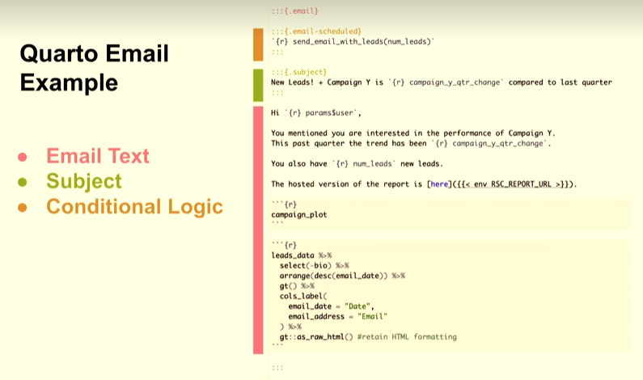

- posit Connect
  - Can control email recipients with groups
  - Can schedule - can specify when it renders (email will only be sent if it meets your conditional logic step)
- Considerations with Quarto emails
  - Static visualizations
  - Table constraints
  - Limited interactivity
- Quarto email tips
  - Focus on key metrics
  - Use dynamic subject lines
  - Be selective with delivery criteria
  - Think about “so what”

#### Automated Reporting With Quarto: Beyond Copy and Paste

**Session Info**

- Presenter: Orla Doyle
- A pharmaceutical company (Novartis) created a package ({rdocx}) that generates reproducible word documents using R Markdown using a company template
  - Mandatory elements are represented as R6 classes where each attribute has a unique input requirement that goes through a series of checks
  - Embedded good software development practices

#### Quarto: A Multifaceted Publishing Powerhouse for Medical Researchers

**Session Info**

- Presenter: Joshua Cook
- Quarto allows us to efficiency create various polished formats from a single source document (in this case, stored in the /Analysis folder)
  - Never include all of your code in one Quarto markdown; use shortcodes instead to import analyses/figures, etc. so that you can output the same figure in multiple formats (e.g., PPT/PDF Manuscript, etc.)
  - If an error is identified or something about the data, tables, or figures needs to be changed, simply altering the files in /Analysis will prompt all the documents to update when they are next rendered.
- Quarto shortcodes: special markdown directives that generate content
  - Key shortcodes:
    - embed - embeds cells from Quarto markdown (.qmd) file or a Jupyter (.ipynb) notebook (`{{< embed Analysis/data_missing.qmd#fig-missing-1 >}} # will only include a SPECIFIC figure`)
    - include - direct copy/paste of content from another Quarto markdown or Jupyter notebook (``{{< include Analysis/data.processing.qmd >}} # will include EVERYTHING from the file`)
- Advanced features
  - In-line programming
  - Dynamically updating - using quarto.yml
    - `execute: freeze: auto` to auto-update if any changes detected in the files
  - Templates
  - Collaboration tools available - notes, highlighting, commenting with Hypothesis
  - Works with Zotero libraries

### Is It Supposed To Hurt This Much?

```markdown
Tuesday, Aug 13 2:40 PM - 4:00 PM PDT
```

#### “Please Let Me Merge Before I Start Crying”: And Other Things I’ve Said at the Git Terminal

**Session Info**

- Presenter: Meghan Harris
- Git =/= GitHub
  - Git: Version control system
  - GitHub: Developer platform that uses Git software
- Three ways (R users) can interact with Git
  - A CLI terminal
  - R Studio GUI
  - A Third Party Client (e.g., GitHub Desktop)
- What is Git merge?
  - Join two or more development histories (branches) together
- What is a Git merge conflict?
  - Content conflict: Competing changes are made to the same line of a file
  - Structure conflict: When someone edits a file and someone else deletes the same file
- Resolving Git merge conflicts
  - Don’t panic and abort merge
    - Terminal: `git merge --abort`
  - Assess the damage
    - Terminal: `git status`
  - Choose your own adventure - you are in control to choose what version you want
- Merge conflicts are not Git problems, but are communication problems, workflow problems, knowledge gap problems
  - Communication
    - Talking with others
    - Naming/styling conventions
    - Consistent formatting
    - Leverage developer platforms
      - “Pull request templates”
      - “Labels”
      - “Issues”
      - “Pull Request Comments”
      - “Branch Rules and Protection”
  - Workflow
    - Before you code:
      - Check Git environment
      - Check branch status and “drift”
      - ALWAYS pull first before touching ANYTHING
    - During your coding:
      - Commit often (with repeated amends)
      - Push thoughtfully but consider “branch drift” risk
      - Use git stashes when there’s “emergencies”
    - After you code
      - Leave nothing behind
      - You are reviewer #1

#### Easing the pain of connecting to databases

**Session Info**

- Presenter: Edgar Ruiz
- Improvements to the [`odbc` R package](https://cran.r-project.org/web/packages/odbc/index.html)
  - Connecting to Databricks/Snowflakes becomes simpler
    - `odbc::databricks()`
    - `odbc::snowflake()`
  - Flexible ways to authenticate
    - Use browser-based SSO (currently in the development version; only for desktops)
    - Use a traditional username & PW
- DB Connection Pane in Positron

#### Auth is the product, making data access simple with Posit Workbench

**Session Info**

- Presenter: Aaron Jacobs
- Posit Public Package Manager (P3M)
  - A free, hosted service based on our professional Posit Package Manager
  - Provides everything in a complete CRAN mirror, plus many additional features
  - Used widely in the R community since 2020, with over 40 million package installs each month
  - Designed to address common pain points in using public mirrors
- Package pain: My code used to work, but now it doesn’t
  - Why does this happen?
    - New versions may have changes that break old code
    - Dependent packages may be out-of-date
      - CRAN only guarantees package compatibility at any given “latest” point in time
    - Packages are no longer available
  - How P3M helps
    - Posit takes daily snapshots of CRAN, PyPI, and Bioconductor
    - Users can configure R to install packages from a specific date, ensuring all packages installed from that snapshot are compatible with each other
  - How can I use snapshots?
    - Recreate the package environment for an old project easily by knowing when the project was originally written
    - Future-proof your work by tying it to today’s snapshot when sharing with others or reproducing it later
- Package pain: Installing packages is really slow
  - Why does this happen?
    - Installing packages from source is slow
      - Any C, C++, or Fortran code needs to be compiled
      - Many packages require additional libraries and build tools
    - Binary packages reduce installation time by pre-building the package
    - CRAN only provides binary packages for Windows and macOS on the current and previous version of R
  - How P3M helps
    - Pre-built binary packages for all of CRAN
      - On the current plus 5 previous R versions
      - For Windows, macOS, and 12 Linux distributions
    - Also ideal for cloud compute and containerized environments where package installation is repetitive and automated
  - Package binary builds
- [p3m.dev](https://p3m.dev/client/#/)
- Using P3M as your CRAN repository
  - `options("repos)` in R
  - RStudio -> Global Options -> Packages
  - Get detailed instructions specifically for your R environment on the Public Package Manager Setup page